# Project 3 part 2

Isaac Johnson & Jesse DeBolt

04/11/2023

NOTE: We had some issues trying to merge our two documents, this document in additional to our original submit should be considered the project as a whole. Some EDA is included in part 1, the original submission as well as the PCA section and some modeling. This document contains the K-Means clustering section as well as some additional EDA and modeling.

## Setup

```r
knitr::opts_chunk$set(echo = TRUE, message = FALSE, warning = FALSE)
library(tidyverse)
library(tidytext)
library(caret)
library(fastDummies)
library(randomForest)
library(broom)
# https://www.openml.org/d/1590

raw_income = read_csv("./openml_1590.csv", na=c("?"))

income = read_csv("./openml_1590.csv", na=c("?")) %>%
  drop_na() %>%
  mutate(income_above_50k = class==">50K") %>%
  select(-class) %>%
  dummy_cols(remove_selected_columns = T)

head(income)
```

| age | fnlwgt | education-num | capital-gain | capital-loss | hours-per-week | income_above_50k | workclass_Federal-gov | workclass_Local-gov | workclass_Private | workclass_Self-emp-inc | workclass_Self-emp-not-inc | workclass_State-gov | workclass_Without-pay | education_1st-4th | education_5th-6th | education_7th-8th | education_9th | education_10th | education_11th | education_12th | education_Assoc-acdm | education_Assoc-voc | education_Bachelors | education_Doctorate | education_HS-grad | education_Masters | education_Preschool | education_Prof-school | education_Some-college | … |
| --- | --- | --- | --- | --- | --- | --- | --- | --- | --- | --- | --- | --- | --- | --- | --- | --- | --- | --- | --- | --- | --- | --- | --- | --- | --- | --- | --- | --- | --- | --- |
| 25 | 226802 | 7 | 0 | 0 | 40 | FALSE | 0 | 0 | 1 | 0 | 0 | 0 | 0 | 0 | 0 | 0 | 0 | 0 | 1 | 0 | 0 | 0 | 0 | 0 | 0 | 0 | 0 | 0 | 0 | … |
| 38 | 89814 | 9 | 0 | 0 | 50 | FALSE | 0 | 0 | 1 | 0 | 0 | 0 | 0 | 0 | 0 | 0 | 0 | 0 | 0 | 0 | 0 | 0 | 0 | 0 | 1 | 0 | 0 | 0 | 0 | … |
| 28 | 336951 | 12 | 0 | 0 | 40 | TRUE | 0 | 1 | 0 | 0 | 0 | 0 | 0 | 0 | 0 | 0 | 0 | 0 | 0 | 0 | 1 | 0 | 0 | 0 | 0 | 0 | 0 | 0 | 0 | … |
| 44 | 160323 | 10 | 7688 | 0 | 40 | TRUE | 0 | 0 | 1 | 0 | 0 | 0 | 0 | 0 | 0 | 0 | 0 | 0 | 0 | 0 | 0 | 0 | 0 | 0 | 0 | 0 | 0 | 0 | 1 | … |
| 34 | 198693 | 6 | 0 | 0 | 30 | FALSE | 0 | 0 | 1 | 0 | 0 | 0 | 0 | 0 | 0 | 0 | 0 | 1 | 0 | 0 | 0 | 0 | 0 | 0 | 0 | 0 | 0 | 0 | 0 | … |
| 63 | 104626 | 15 | 3103 | 0 | 32 | TRUE | 0 | 0 | 0 | 0 | 1 | 0 | 0 | 0 | 0 | 0 | 0 | 0 | 0 | 0 | 0 | 0 | 0 | 0 | 0 | 0 | 0 | 1 | 0 | … |

##preprocessing before K-means clustering

```r
#preprocessing data
income_scaled <- income %>%
    mutate(age=scale(age), fnlwgt=scale(fnlwgt), `education-num`=scale(`education-num`), `capital-gain`=scale(`capital-gain`), `capital-loss`=scale(`capital-loss`), `hours-per-week`=scale(`hours-per-week`))
```

##Basic K-means clustering

```r
#setting # of clusters to 3 (that's K)
kclust <- kmeans(income_scaled, centers = 3)
kclust$centers
```

```
##          age      fnlwgt education-num capital-gain capital-loss hours-per-week
## 1  0.2445702 -0.01456681     0.3582008   -0.1467316    4.4693477      0.2328848
## 2  0.5105878 -0.10131843     0.1756853    0.1340072   -0.2178724      0.3515602
## 3 -0.5502390  0.10583335    -0.2163851   -0.1235900   -0.2167648     -0.3852285
##   income_above_50k workclass_Federal-gov workclass_Local-gov workclass_Private
## 1       0.52265141            0.03862661          0.08154506         0.6742966
## 2       0.42718757            0.03806260          0.08192826         0.6461503
## 3       0.03592279            0.02316384          0.05348399         0.8357815
##   workclass_Self-emp-inc workclass_Self-emp-not-inc workclass_State-gov
## 1            0.063900811                 0.10109680          0.04005722
## 2            0.059401416                 0.12890107          0.04496230
## 3            0.009981168                 0.03592279          0.04133710
##   workclass_Without-pay education_1st-4th education_5th-6th education_7th-8th
## 1          0.0004768717       0.002861230       0.007153076        0.01144492
## 2          0.0005940142       0.003975326       0.006899703        0.02010509
```

[output cut: 121 more lines]

```r
glance(kclust)
```

| totss | tot.withinss | betweenss | iter |
| --- | --- | --- | --- |
| 477996.6 | 387989.6 | 90007.03 | 3 |

##Add Clusters to original dataset

```r
incomek <- augment(kclust,income_scaled)
head(incomek)
```

| age | fnlwgt | education-num | capital-gain | capital-loss | hours-per-week | income_above_50k | workclass_Federal-gov | workclass_Local-gov | workclass_Private | workclass_Self-emp-inc | workclass_Self-emp-not-inc | workclass_State-gov | workclass_Without-pay | education_1st-4th | education_5th-6th | education_7th-8th | education_9th | education_10th | education_11th | education_12th | education_Assoc-acdm | education_Assoc-voc | education_Bachelors | education_Doctorate | education_HS-grad | education_Masters | education_Preschool | education_Prof-school | education_Some-college | … |
| --- | --- | --- | --- | --- | --- | --- | --- | --- | --- | --- | --- | --- | --- | --- | --- | --- | --- | --- | --- | --- | --- | --- | --- | --- | --- | --- | --- | --- | --- | --- |
| -1.02497158 | 0.35088554 | -1.22154531 | -0.1467316 | -0.2187778 | -0.0781192 | FALSE | 0 | 0 | 1 | 0 | 0 | 0 | 0 | 0 | 0 | 0 | 0 | 0 | 1 | 0 | 0 | 0 | 0 | 0 | 0 | 0 | 0 | 0 | 0 | … |
| -0.04145458 | -0.94586800 | -0.43811676 | -0.1467316 | -0.2187778 | 0.7546931 | FALSE | 0 | 0 | 1 | 0 | 0 | 0 | 0 | 0 | 0 | 0 | 0 | 0 | 0 | 0 | 0 | 0 | 0 | 0 | 1 | 0 | 0 | 0 | 0 | … |
| -0.79800612 | 1.39357618 | 0.73702606 | -0.1467316 | -0.2187778 | -0.0781192 | TRUE | 0 | 1 | 0 | 0 | 0 | 0 | 0 | 0 | 0 | 0 | 0 | 0 | 0 | 0 | 1 | 0 | 0 | 0 | 0 | 0 | 0 | 0 | 0 | … |
| 0.41247634 | -0.27841687 | -0.04640249 | 0.8774570 | -0.2187778 | -0.0781192 | TRUE | 0 | 0 | 1 | 0 | 0 | 0 | 0 | 0 | 0 | 0 | 0 | 0 | 0 | 0 | 0 | 0 | 0 | 0 | 0 | 0 | 0 | 0 | 1 | … |
| -0.34407519 | 0.08480059 | -1.61325958 | -0.1467316 | -0.2187778 | -0.9109315 | FALSE | 0 | 0 | 1 | 0 | 0 | 0 | 0 | 0 | 0 | 0 | 0 | 1 | 0 | 0 | 0 | 0 | 0 | 0 | 0 | 0 | 0 | 0 | 0 | … |
| 1.84992426 | -0.80565489 | 1.91216887 | 0.2666473 | -0.2187778 | -0.7443690 | TRUE | 0 | 0 | 0 | 0 | 1 | 0 | 0 | 0 | 0 | 0 | 0 | 0 | 0 | 0 | 0 | 0 | 0 | 0 | 0 | 0 | 0 | 1 | 0 | … |

##Visualize Clusters

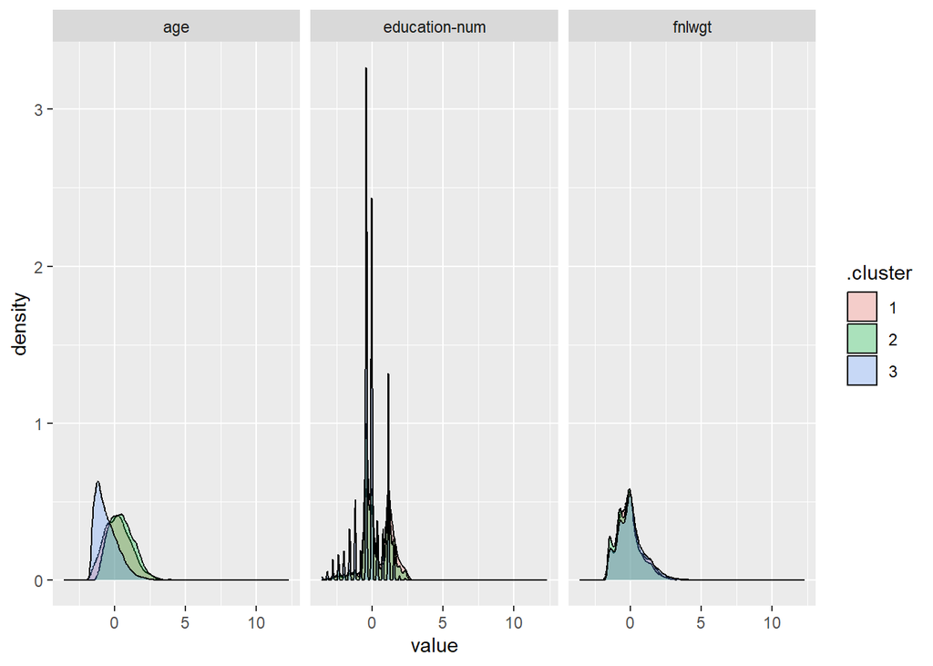

```r
incomek %>%
  pivot_longer(c(age, fnlwgt, `education-num`),names_to = "feature") %>%
  ggplot(aes(value, fill=.cluster))+
  geom_density(alpha=0.3)+
  facet_wrap(~feature)
```

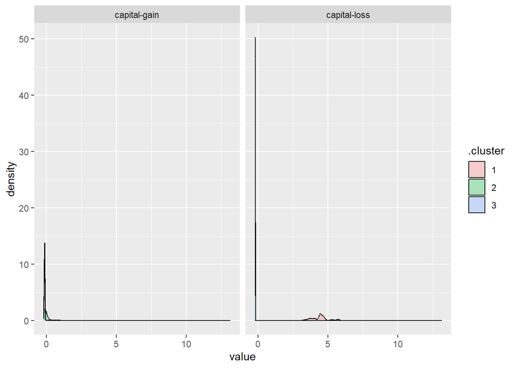

```r
incomek %>%
  pivot_longer(c(`capital-gain`,`capital-loss`),names_to = "feature") %>%
  ggplot(aes(value, fill=.cluster))+
  geom_density(alpha=0.3)+
  facet_wrap(~feature)
```

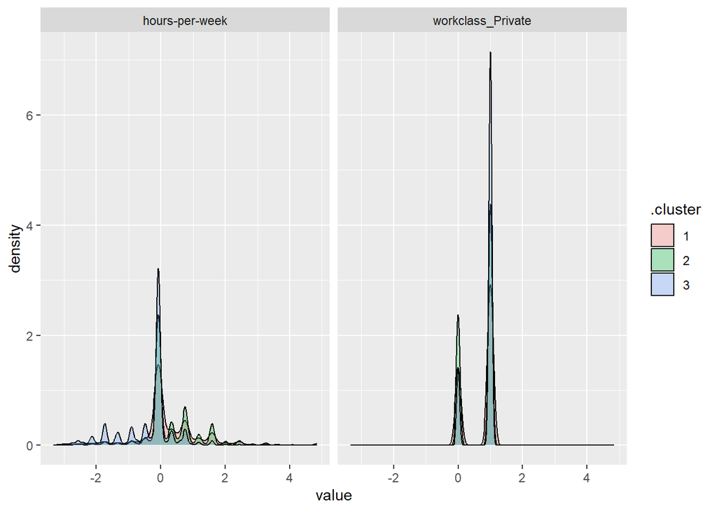

```r
incomek %>%
  pivot_longer(c(`hours-per-week`,workclass_Private),names_to = "feature") %>%
  ggplot(aes(value, fill=.cluster))+
  geom_density(alpha=0.3)+
  facet_wrap(~feature)
```

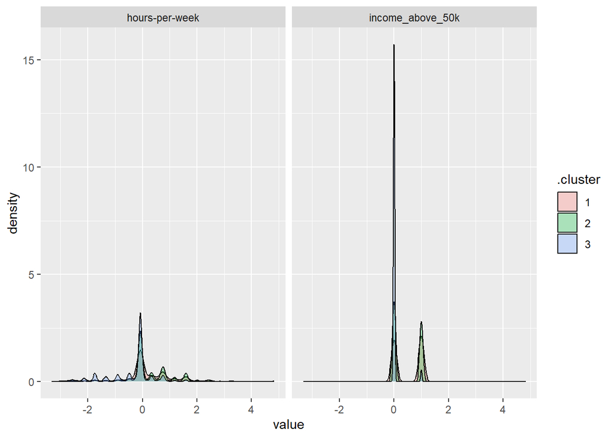

```r
incomek %>%
  pivot_longer(c(`hours-per-week`,income_above_50k),names_to = "feature") %>%
  ggplot(aes(value, fill=.cluster))+
  geom_density(alpha=0.3)+
  facet_wrap(~feature)
```

##Try different numbers of clusters

```r
kclusts <- tibble(k = 1:9) %>%
  mutate(
    kclust = map(k, ~kmeans(income_scaled, .x)),
    glanced = map(kclust, glance),
    augmented = map(kclust, augment, income_scaled)
  )
```

##Plot the different clusters on two axes

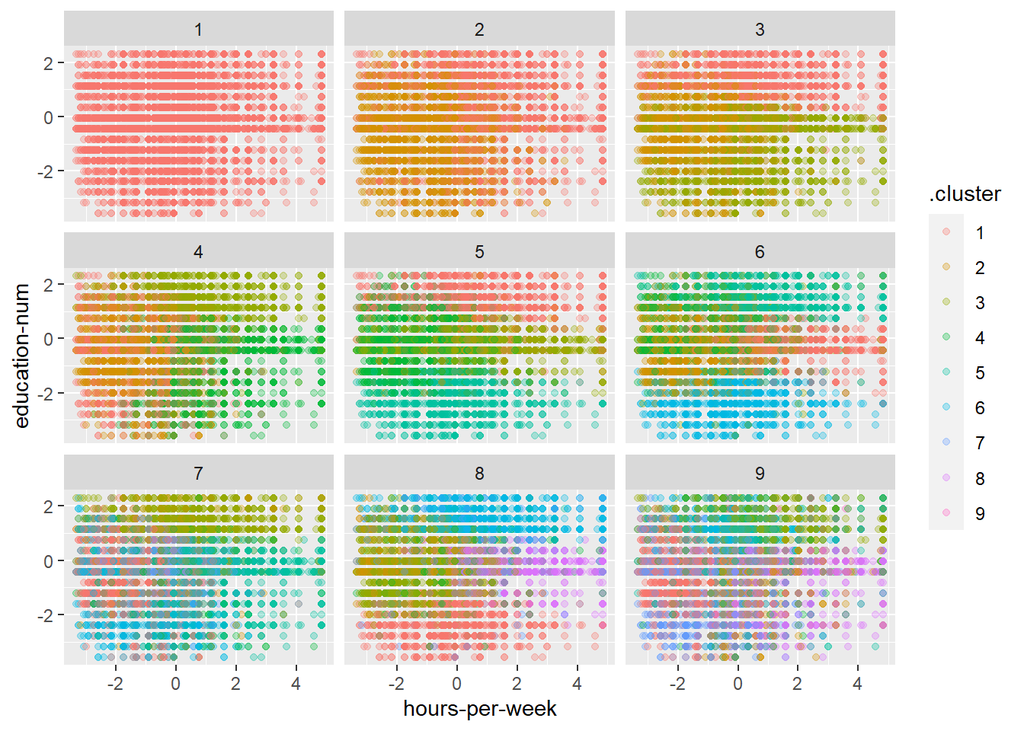

```r
assignments <- kclusts %>%
  unnest(augmented)


ggplot(assignments, aes(`hours-per-week`, `education-num`)) +
  geom_point(aes(color = .cluster), alpha=0.3) +
  facet_wrap(~ k)
```

##Look at improvement in within-cluster error

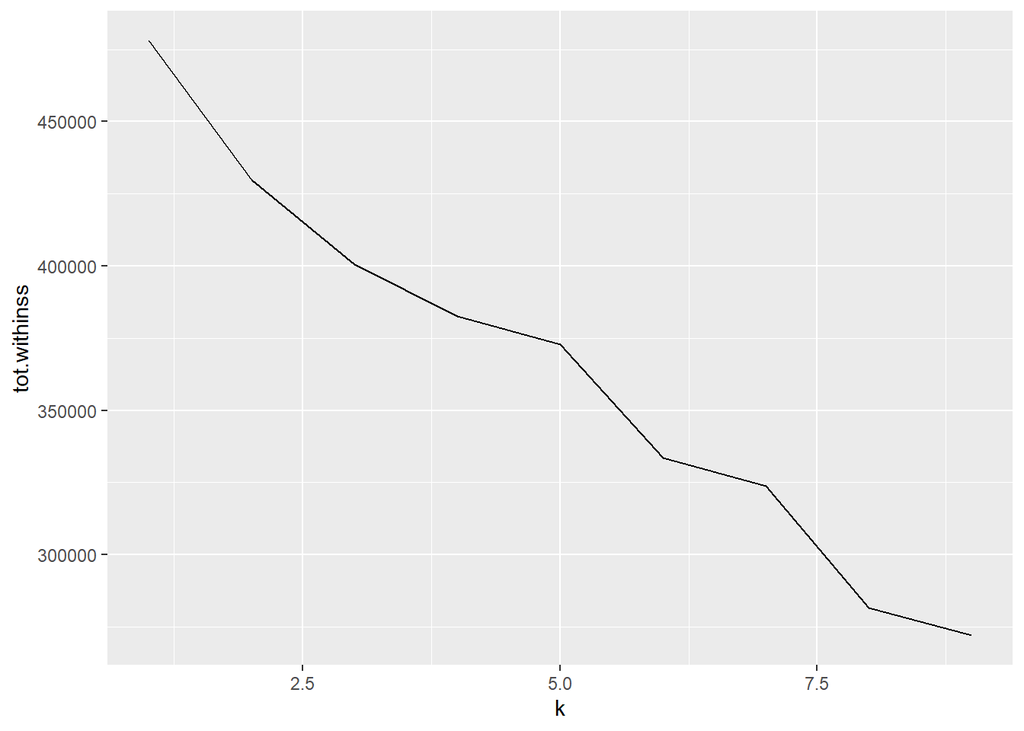

```r
#can still look for elbow (looks like about 7)
clusterings <- kclusts %>%
  unnest(glanced, .drop = TRUE)

ggplot(clusterings, aes(k, tot.withinss)) +
  geom_line()
```

```r
# Run k-means with the optimal number of clusters
optimal_k <- 7
kclust_optimal <- kmeans(income_scaled, centers = optimal_k)

# Check the cluster centroids
kclust_optimal$centers
```

```
##          age      fnlwgt education-num capital-gain capital-loss hours-per-week
## 1  0.2811905 -0.01991569     0.4391811  1.170490920    4.0131944     0.29269082
## 2 -0.9874263 -0.21282269    -0.4571985 -0.130715167   -0.2177665    -0.57333249
## 3  0.1861035 -0.23762267     0.1222381 -0.002318577   -0.2172319     2.02041306
## 4  0.2771704 -0.24973031     0.3450352 -0.004397127   -0.2187778     0.10789832
## 5 -0.3409739  1.89471716    -0.3531820 -0.095595701   -0.2142706    -0.03566104
## 6  1.1194761 -0.25560245    -0.8138196 -0.096818010   -0.2146554    -0.36873239
## 7 -0.1543553 -0.17583818     1.1343779 -0.029037788   -0.2145012    -0.03021699
##   income_above_50k workclass_Federal-gov workclass_Local-gov workclass_Private
## 1       0.57210708            0.03583765          0.07599309         0.6593264
## 2       0.01424082            0.01483009          0.03457081         0.8807700
## 3       0.38062083            0.01885698          0.04931825         0.5607775
## 4       0.50569235            0.04227341          0.07377990         0.6853764
## 5       0.15814455            0.03214671          0.05480043         0.8040992
## 6       0.08959538            0.03248004          0.07225434         0.7358932
```

[output cut: 257 more lines]

```r
# Run k-means with 7 clusters
kclust <- kmeans(income_scaled, centers = 7)

# Print the cluster centers
print(kclust$centers)
```

```
##          age      fnlwgt education-num capital-gain capital-loss hours-per-week
## 1 -1.0136505 -0.23181823    -0.2353646  -0.12948475   -0.2176230   -0.549639571
## 2  0.2743224 -0.17854758     1.2877835   0.06309096   -0.2174573    0.371982595
## 3  0.2448121 -0.01696940     0.3582378  -0.14673158    4.4744694    0.233378873
## 4  0.5994668 -0.04106179     1.1629512  13.17504707   -0.2187778    0.827791426
## 5 -0.3820522  1.88758191    -0.2338291  -0.09585794   -0.2149713    0.008538997
## 6  0.3026919 -0.27234850    -0.5156503  -0.06528065   -0.2185774    0.456687301
## 7  0.9220009 -0.26724199    -0.4973770  -0.09832922   -0.2138802   -0.428967509
##   income_above_50k workclass_Federal-gov workclass_Local-gov workclass_Private
## 1       0.01437278           0.015191485          0.03875193         0.8721914
## 2       0.53815962           0.046445704          0.11960314         0.5919102
## 3       0.52415112           0.038737446          0.08130081         0.6743185
## 4       1.00000000           0.008733624          0.02620087         0.5240175
## 5       0.15325431           0.034934498          0.05822416         0.7970472
## 6       0.31949825           0.027485704          0.05589375         0.7069729
```

[output cut: 257 more lines]

##Outliers lof

```r
library(dbscan)
lof <- lof(income, minPts = 10)
summary(lof)
```

```
##    Min. 1st Qu.  Median    Mean 3rd Qu.    Max.
##  0.8445  0.9905  1.0202  1.2133  1.1030 49.1007
```

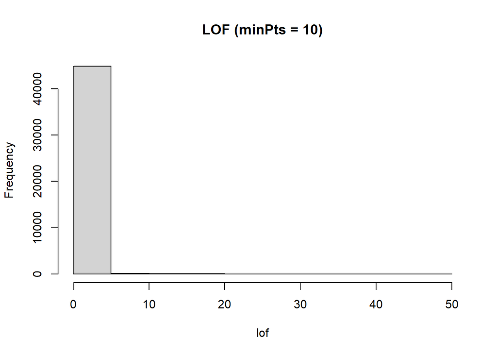

```r
hist(lof, breaks = 10, main = "LOF (minPts = 10)")
```

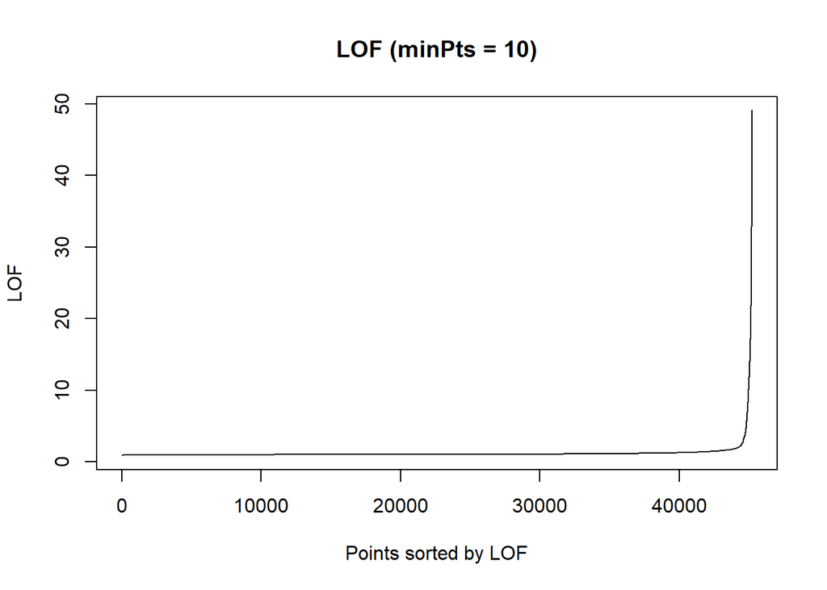

```r
plot(sort(lof), type = "l",  main = "LOF (minPts = 10)",
  xlab = "Points sorted by LOF", ylab = "LOF")
```

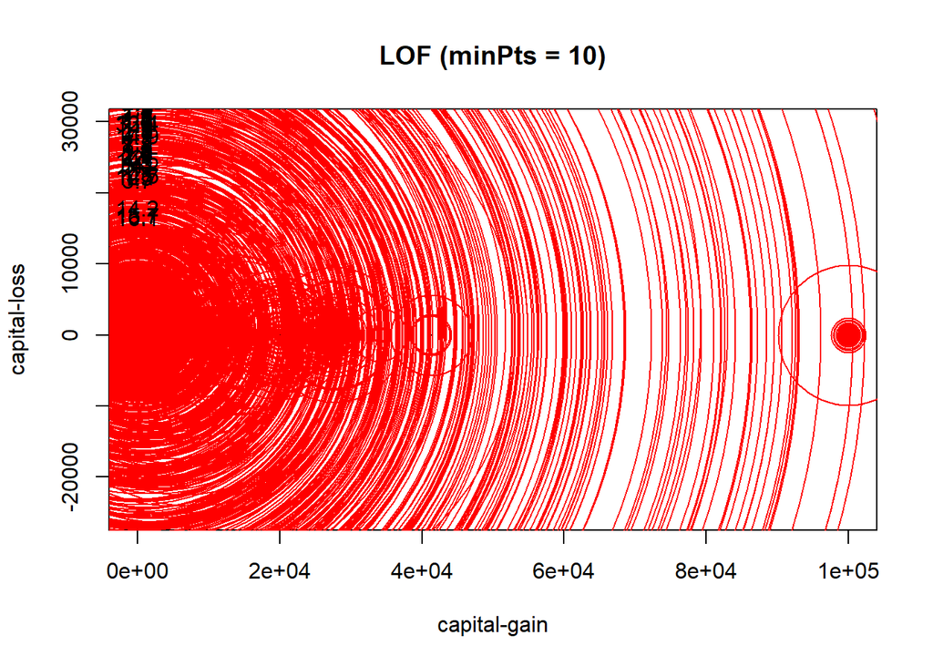

```r
#capital gain/loss
plot(select(income, c("capital-gain", "capital-loss")), pch = ".", main = "LOF (minPts = 10)", asp = 1)
points(select(income, c("capital-gain", "capital-loss")), cex = (lof - 1) * 4, pch = 1, col = "red")
text(income[lof > 1.3,], labels = round(lof, 1)[lof > 1.3], pos = 3)
```

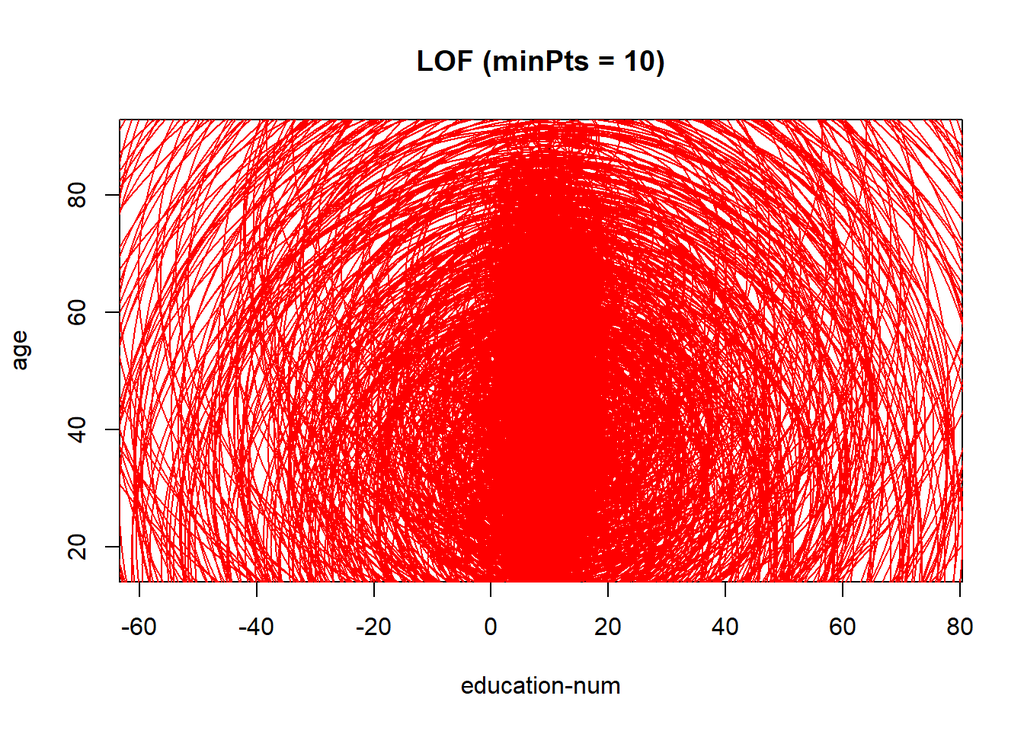

```r
#education age
plot(select(income, c("education-num", "age")), pch = ".", main = "LOF (minPts = 10)", asp = 1)
points(select(income, c("education-num", "age")), cex = (lof - 1) * 4, pch = 1, col = "red")
text(income[lof > 1.3,], labels = round(lof, 1)[lof > 1.3], pos = 3)
```

##Outliers isolation forest

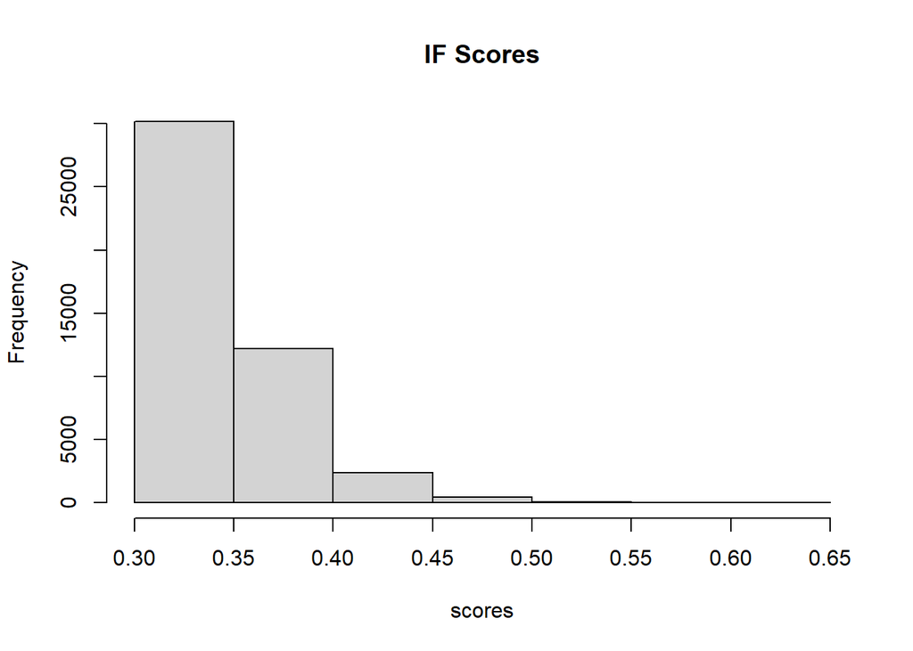

```r
library(isotree)
model = isolation.forest(income, ndim=1, ntrees=10)
scores = predict(model, income, type="score")
hist(scores, breaks = 10, main = "IF Scores")
```

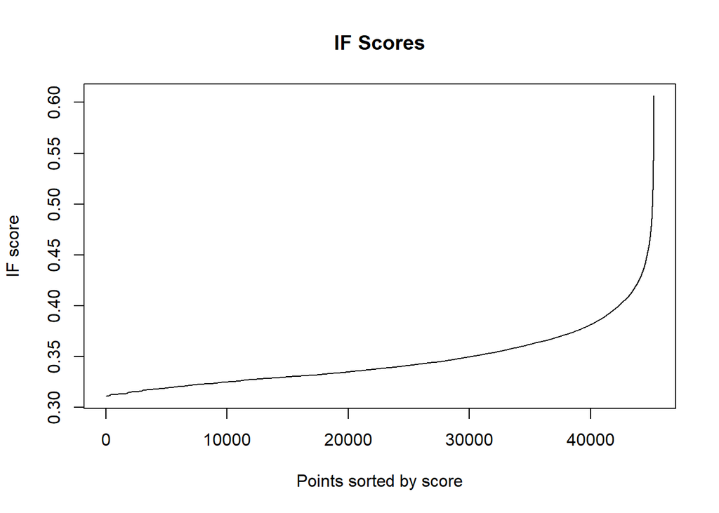

```r
plot(sort(scores), type = "l",  main = "IF Scores",
  xlab = "Points sorted by score", ylab = "IF score")
```

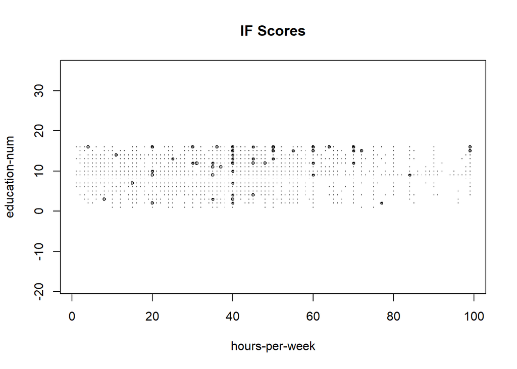

```r
plot(select(income, c(`hours-per-week`, `education-num`)), pch = ".", main = "IF Scores", asp = 1)
points(select(income, c(`hours-per-week`, `education-num`))[scores > 0.5,], cex = as.data.frame(scores)[scores > 0.5,])
```

##Model Kmeans CLusters Kappa .57

```r
#income$income_above_50k <- as.factor(income$income_above_50k)
incomek$income_above_50k <- factor(incomek$income_above_50k, levels = c(FALSE, TRUE), labels = c("Below_50K", "Above_50K"))


#timer
start_time <- Sys.time()


# specify the model to be used (i.e. KNN, Naive Bayes, decision tree, random forest, bagged trees) and the tuning parameters used
ctrl <- trainControl(method = "cv", number = 3, classProbs = TRUE, summaryFunction = twoClassSummary)
set.seed(504)

income_index <- createDataPartition(incomek$income_above_50k, p = 0.80, list = FALSE)
train <- incomek[ income_index, ]
test <- incomek[-income_index, ]

# example spec for rf
fit <- train(income_above_50k ~ .,
             data = train,
             method = "rf",
             ntree = 20,
             tuneLength = 3,
             metric = "ROC",
             trControl = ctrl)

fit
```

```
## Random Forest
##
## 36179 samples
##   105 predictor
##     2 classes: 'Below_50K', 'Above_50K'
##
## No pre-processing
## Resampling: Cross-Validated (3 fold)
## Summary of sample sizes: 24119, 24120, 24119
## Resampling results across tuning parameters:
##
##   mtry  ROC        Sens       Spec
##     2   0.8643792  0.9674409  0.3705810
##    54   0.8990224  0.9259885  0.6304227
##   106   0.8946556  0.9205129  0.6308687
##
## ROC was used to select the optimal model using the largest value.
## The final value used for the model was mtry = 54.
```

```r
confusionMatrix(predict(fit, test),factor(test$income_above_50k))
```

```
## Confusion Matrix and Statistics
##
##            Reference
## Prediction  Below_50K Above_50K
##   Below_50K      6289       836
##   Above_50K       513      1405
##
##                Accuracy : 0.8508
##                  95% CI : (0.8433, 0.8581)
##     No Information Rate : 0.7522
##     P-Value [Acc > NIR] : < 2.2e-16
##
##                   Kappa : 0.5795
##
##  Mcnemar's Test P-Value : < 2.2e-16
##
##             Sensitivity : 0.9246
##             Specificity : 0.6270
##          Pos Pred Value : 0.8827
##          Neg Pred Value : 0.7325
##              Prevalence : 0.7522
##          Detection Rate : 0.6955
##    Detection Prevalence : 0.7879
##       Balanced Accuracy : 0.7758
##
##        'Positive' Class : Below_50K
##
```

```r
#end timer
end_time <- Sys.time()
time_taken <- end_time - start_time
print(time_taken)
```

```
## Time difference of 1.064544 mins
```

```r
print(as.numeric(time_taken, units = "mins"))
```

```
## [1] 1.064544
```

##Model kappa .57 with no feature engineering

```r
#income$income_above_50k <- as.factor(income$income_above_50k)
income$income_above_50k <- factor(income$income_above_50k, levels = c(FALSE, TRUE), labels = c("Below_50K", "Above_50K"))


#timer
start_time <- Sys.time()


# specify the model to be used (i.e. KNN, Naive Bayes, decision tree, random forest, bagged trees) and the tuning parameters used
ctrl <- trainControl(method = "cv", number = 3, classProbs = TRUE, summaryFunction = twoClassSummary)
set.seed(504)

income_index <- createDataPartition(income$income_above_50k, p = 0.80, list = FALSE)
train <- income[ income_index, ]
test <- income[-income_index, ]

# example spec for rf
fit <- train(income_above_50k ~ .,
             data = train,
             method = "rf",
             ntree = 20,
             tuneLength = 3,
             metric = "ROC",
             trControl = ctrl)

fit
```

```
## Random Forest
##
## 36179 samples
##   104 predictor
##     2 classes: 'Below_50K', 'Above_50K'
##
## No pre-processing
## Resampling: Cross-Validated (3 fold)
## Summary of sample sizes: 24119, 24120, 24119
## Resampling results across tuning parameters:
##
##   mtry  ROC        Sens       Spec
##     2   0.8618802  0.9841979  0.2572767
##    53   0.8939580  0.9256209  0.6237315
##   104   0.8902885  0.9217991  0.6268540
##
## ROC was used to select the optimal model using the largest value.
## The final value used for the model was mtry = 53.
```

```r
confusionMatrix(predict(fit, test),factor(test$income_above_50k))
```

```
## Confusion Matrix and Statistics
##
##            Reference
## Prediction  Below_50K Above_50K
##   Below_50K      6277       849
##   Above_50K       525      1392
##
##                Accuracy : 0.8481
##                  95% CI : (0.8405, 0.8554)
##     No Information Rate : 0.7522
##     P-Value [Acc > NIR] : < 2.2e-16
##
##                   Kappa : 0.5717
##
##  Mcnemar's Test P-Value : < 2.2e-16
##
##             Sensitivity : 0.9228
##             Specificity : 0.6212
##          Pos Pred Value : 0.8809
##          Neg Pred Value : 0.7261
##              Prevalence : 0.7522
##          Detection Rate : 0.6941
##    Detection Prevalence : 0.7880
##       Balanced Accuracy : 0.7720
##
##        'Positive' Class : Below_50K
##
```

```r
#end timer
end_time <- Sys.time()
time_taken <- end_time - start_time
print(time_taken)
```

```
## Time difference of 1.003401 mins
```

```r
print(as.numeric(time_taken, units = "mins"))
```

```
## [1] 1.003401
```

##EDA

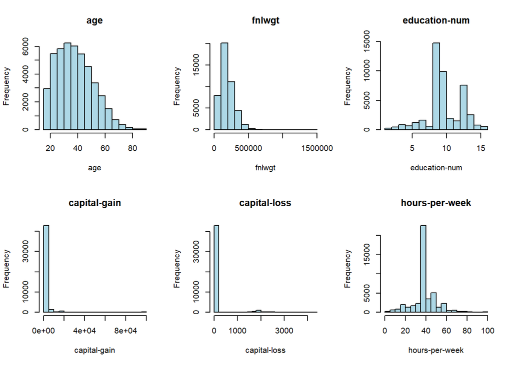

```r
library(ggcorrplot)
library(ggplot2)
library(dplyr)

raw_income = read_csv("./openml_1590.csv", na=c("?"))

income2 = read_csv("./openml_1590.csv", na=c("?")) %>%
  drop_na() %>%
  mutate(income_above_50k = class==">50K") %>%
  select(-class)

##income2$income_above_50k <- as.numeric(factor(income2$income_above_50k, levels = unique(income2$income_above_50k))) - 1
income2$income_above_50k <- as.factor(income2$income_above_50k)
##try2
income2$income_above_50k <- as.numeric(income2$income_above_50k) - 1

#str(income2)

# Set the figure size for the plots
library(ggplot2)
options(repr.plot.width = 20, repr.plot.height = 12)

# Histograms for selected columns
hist_cols <- c("age", "fnlwgt", "education-num", "capital-gain", "capital-loss", "hours-per-week")
par(mfrow=c(2, 3))
for (col in hist_cols) {
  hist(income2[[col]], main=col, xlab=col, col="lightblue")
}
```

####Correlation Matrix Heatmap

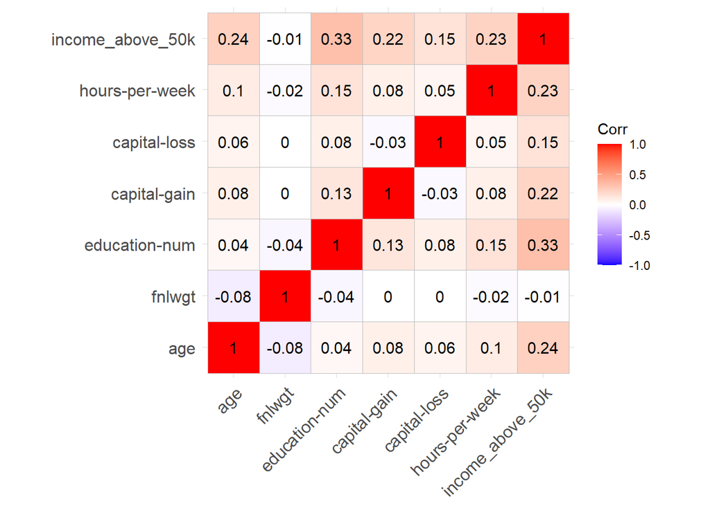

```r
# Select the columns you want to include in the correlation matrix
selected_columns <- c("age", "fnlwgt", "education-num", "capital-gain", "capital-loss", "hours-per-week", "income_above_50k")

# Calculate the correlation matrix for the selected columns
corr_matrix <- cor(income2[, selected_columns])

# Create a heatmap of the correlation matrix with correlation coefficients
ggcorrplot(corr_matrix, lab = TRUE, lab_size = 4, tl.cex = 12, tl.col = "black", tl.srt = 45)
```

##Bucket Age

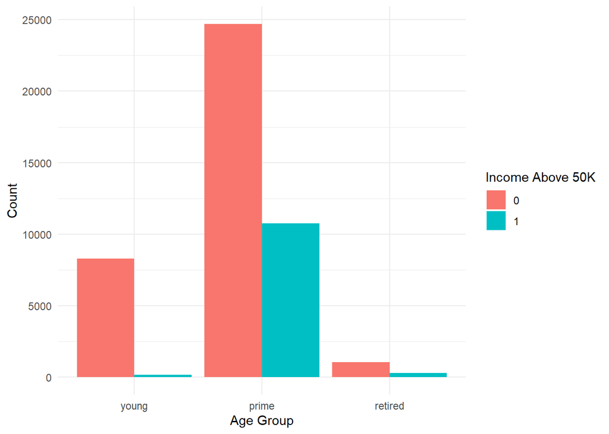

```r
# Bin the 'age' column
income2 <- income2 %>%
  mutate(age_group = case_when(
    age >= 0 & age <= 25 ~ "young",
    age > 25 & age <= 65 ~ "prime",
    age > 65 & age <= 100 ~ "retired"
  )) %>%
    select(-age)

# Reorder the age_group factor levels
income2$age_group <- factor(income2$age_group, levels = c("young", "prime", "retired"))

# Create the count plot with 'income_above_50k' as the hue
ggplot(income2, aes(x = age_group, fill = as.factor(income_above_50k))) +
  geom_bar(position = "dodge") +
  labs(x = "Age Group", y = "Count", fill = "Income Above 50K") +
  theme_minimal()
```

##Capital Diff

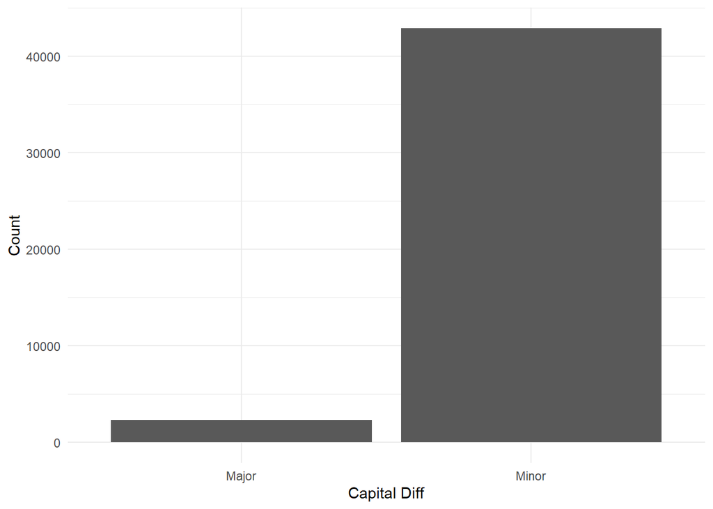

```r
#check if factor
##class(income2$income_above_50k)

# Convert 'income_above_50k' to a factor
##income2$income_above_50k <- as.factor(income2$income_above_50k)
##see above for same in EDA now

# Create 'Capital Diff' column and remove 'Capital Gain' and 'Capital Loss' columns
income2 <- income2 %>%
  mutate(capital_diff = `capital-gain` - `capital-loss`) %>%
  select(-`capital-gain`, -`capital-loss`)

# Bin the 'Capital Diff' column
income2 <- income2 %>%
  mutate(capital_diff = case_when(
    capital_diff >= -5000 & capital_diff <= 5000 ~ "Minor",
    capital_diff > 5000 & capital_diff <= 100000 ~ "Major"
  ))

# Create the count plot with 'Income' as the hue
ggplot(income2, aes(x = capital_diff, fill = income_above_50k)) +
  geom_bar(position = "dodge") +
  labs(x = "Capital Diff", y = "Count", fill = "Income") +
  theme_minimal()
```

##Drop Columns and without pay

```r
income2 <- income2 %>% select(-fnlwgt)

unique(income2$workclass)
```

```
## [1] "Private"          "Local-gov"        "Self-emp-not-inc" "Federal-gov"
## [5] "State-gov"        "Self-emp-inc"     "Without-pay"
```

```r
income2 <- income2 %>%
  filter(workclass != "Without-pay")
```

##Bin Hours

[figure not shown]

```r
# Bin 'Hours per Week' column
income2 <- income2 %>%
  mutate(hours_per_week = case_when(
    `hours-per-week` >= 0 & `hours-per-week` <= 32 ~ "part_time",
    `hours-per-week` > 32 & `hours-per-week` <= 40 ~ "full_time",
    `hours-per-week` > 40 & `hours-per-week` <= 100 ~ "overtime"
  )) %>%
    select(-`hours-per-week`)

#Reorder hours per week
income2$hours_per_week <- factor(income2$hours_per_week, levels = c("part_time", "full_time", "overtime"))


# Create count plot with 'Income' as the hue
ggplot(income2, aes(x = hours_per_week, fill = income_above_50k)) +
  geom_bar(position = "dodge") +
  labs(x = "Hours per Week", y = "Count", fill = "Income") +
  theme_minimal()
```

##Looking at Education

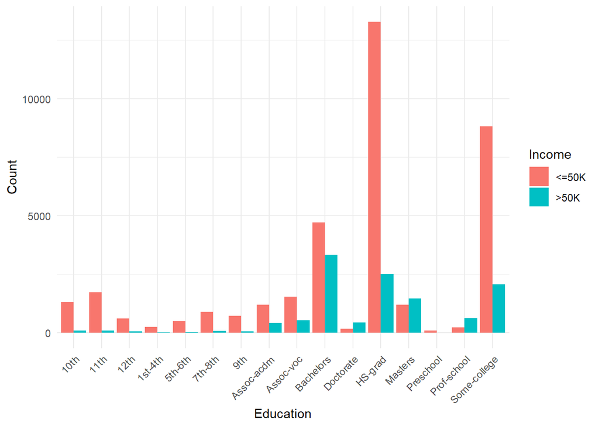

```r
ggplot(raw_income, aes(x = education, fill = class)) +
  geom_bar(position = "dodge") +
  labs(x = "Education", y = "Count", fill = "Income") +
  theme_minimal() +
  theme(axis.text.x = element_text(angle = 45, hjust = 1))
```

##Education same as education-num

```r
income2 %>%
  distinct(education, `education-num`) %>%
  arrange(`education-num`) %>%
  mutate(display = paste0("For ", education, ", the Education Number is ", `education-num`)) %>%
  pull(display) %>%
  print()
```

```
##  [1] "For Preschool, the Education Number is 1"
##  [2] "For 1st-4th, the Education Number is 2"
##  [3] "For 5th-6th, the Education Number is 3"
##  [4] "For 7th-8th, the Education Number is 4"
##  [5] "For 9th, the Education Number is 5"
##  [6] "For 10th, the Education Number is 6"
##  [7] "For 11th, the Education Number is 7"
##  [8] "For 12th, the Education Number is 8"
##  [9] "For HS-grad, the Education Number is 9"
## [10] "For Some-college, the Education Number is 10"
## [11] "For Assoc-voc, the Education Number is 11"
## [12] "For Assoc-acdm, the Education Number is 12"
## [13] "For Bachelors, the Education Number is 13"
## [14] "For Masters, the Education Number is 14"
## [15] "For Prof-school, the Education Number is 15"
## [16] "For Doctorate, the Education Number is 16"
```

##Final Education counts

```r
income2 <- income2 %>%
  select(-`education-num`) %>%
  mutate(education = recode(education,
                            "11th" = "School",
                            "9th" = "School",
                            "7th-8th" = "School",
                            "5th-6th" = "School",
                            "10th" = "School",
                            "1st-4th" = "School",
                            "Preschool" = "School",
                            "12th" = "School"
                            ))

education_counts <- income2 %>%
  count(education) %>%
  arrange(desc(n))

education_counts
```

| education | n |
| --- | --- |
| HS-grad | 14769 |
| Some-college | 9896 |
| Bachelors | 7570 |
| School | 5659 |
| Masters | 2514 |
| Assoc-voc | 1959 |
| Assoc-acdm | 1505 |
| Prof-school | 785 |
| Doctorate | 544 |

##Occupation

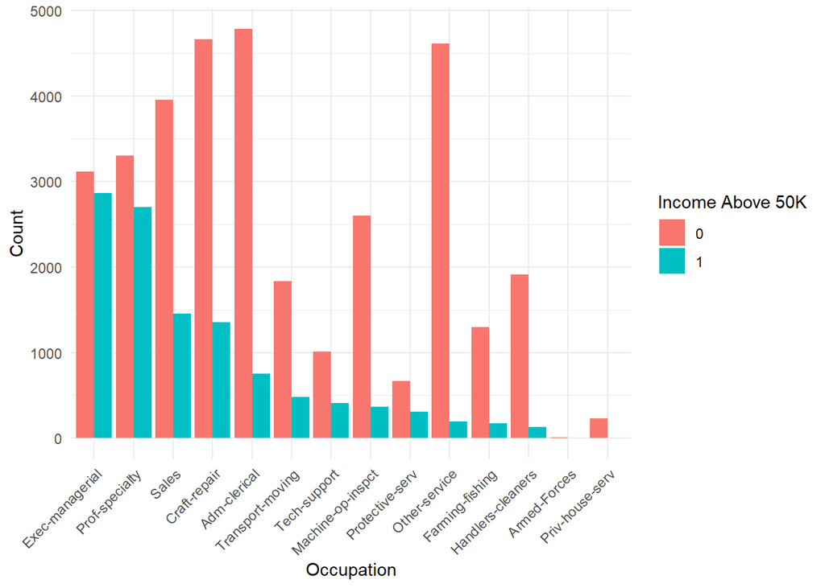

```r
# Calculate the count of 'income_above_50k == 1' for each occupation
occupation_order <- income2 %>%
  filter(income_above_50k == 1) %>%
  group_by(occupation) %>%
  summarize(count = n()) %>%
  arrange(-count) %>%
  pull(occupation)

# Reorder the 'occupation' factor levels based on the calculated order
income2$occupation_ordered <- factor(income2$occupation, levels = occupation_order)

# Create the bar plot
ggplot(income2, aes(x = occupation_ordered, fill = as.factor(income_above_50k))) +
  geom_bar(position = "dodge") +
  theme_minimal() +
  theme(axis.text.x = element_text(angle = 45, hjust = 1)) +
  labs(x = "Occupation", y = "Count", fill = "Income Above 50K")
```

```r
#remove occupation
income2 <- income2 %>%
    select(-occupation)
```

##Race

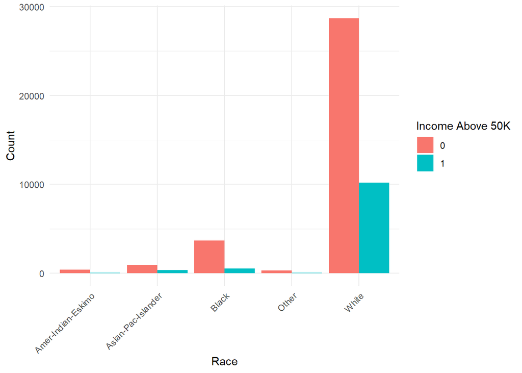

```r
ggplot(income2, aes(x = race, fill = as.factor(income_above_50k))) +
  geom_bar(position = "dodge") +
  theme_minimal() +
  theme(axis.text.x = element_text(angle = 45, hjust = 1, vjust = 1)) +
  labs(x = "Race", y = "Count", fill = "Income Above 50K")
```

```r
unique(income2$race)
```

```
## [1] "Black"              "White"              "Other"
## [4] "Amer-Indian-Eskimo" "Asian-Pac-Islander"
```

```r
income2 <- income2 %>%
  mutate(race = recode(race,
                       "Black" = "Other",
                       "Asian-Pac-Islander" = "Other",
                       "Amer-Indian-Eskimo" = "Other",
                       "Other" = "Other"
                       ))
```

##Sex vs Income

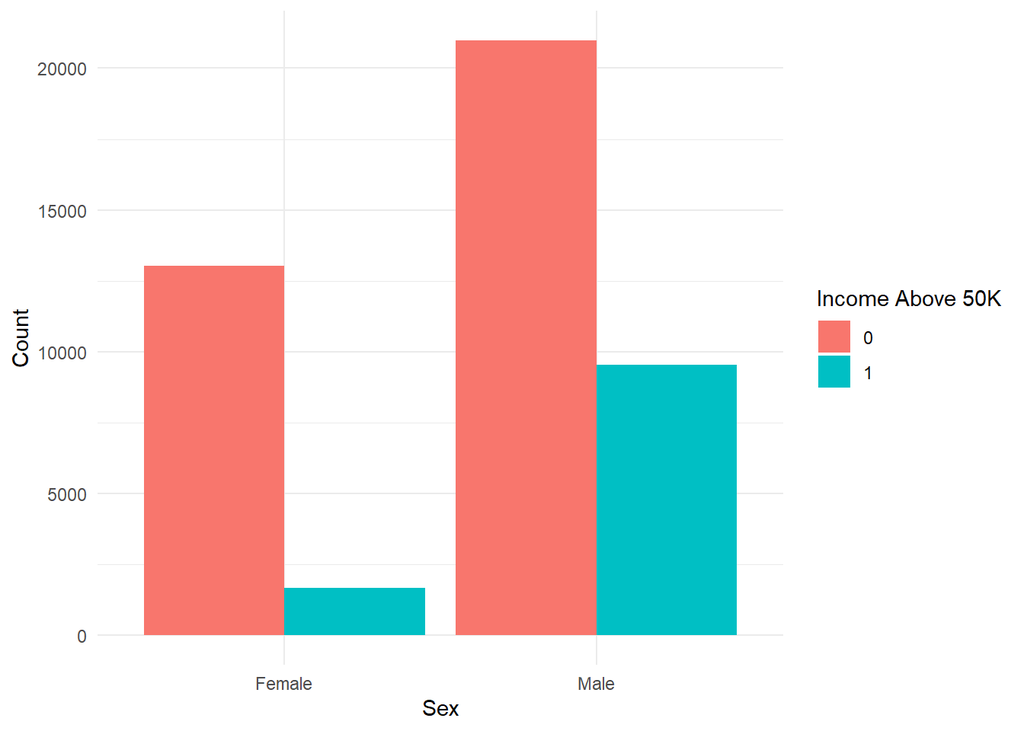

```r
ggplot(income2, aes(x = sex, fill = as.factor(income_above_50k))) +
  geom_bar(position = "dodge") +
  theme_minimal() +
  labs(x = "Sex", y = "Count", fill = "Income Above 50K")
```

##Country

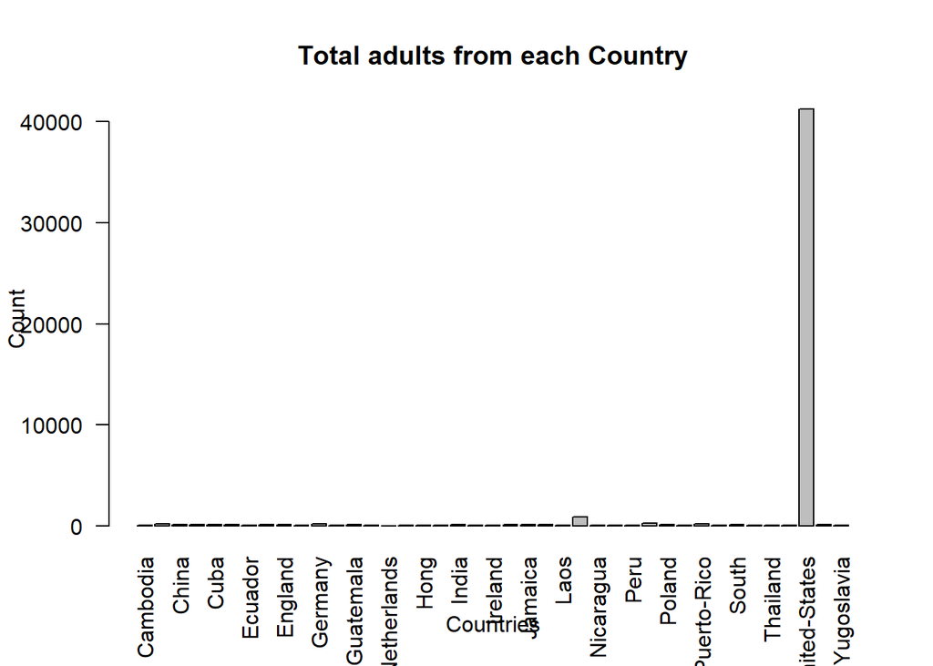

```r
#Count of adults from each country
country_count <- table(income2$`native-country`)
barplot(country_count, xlab = "Countries", ylab = "Count", main = "Total adults from each Country", las = 2)
```

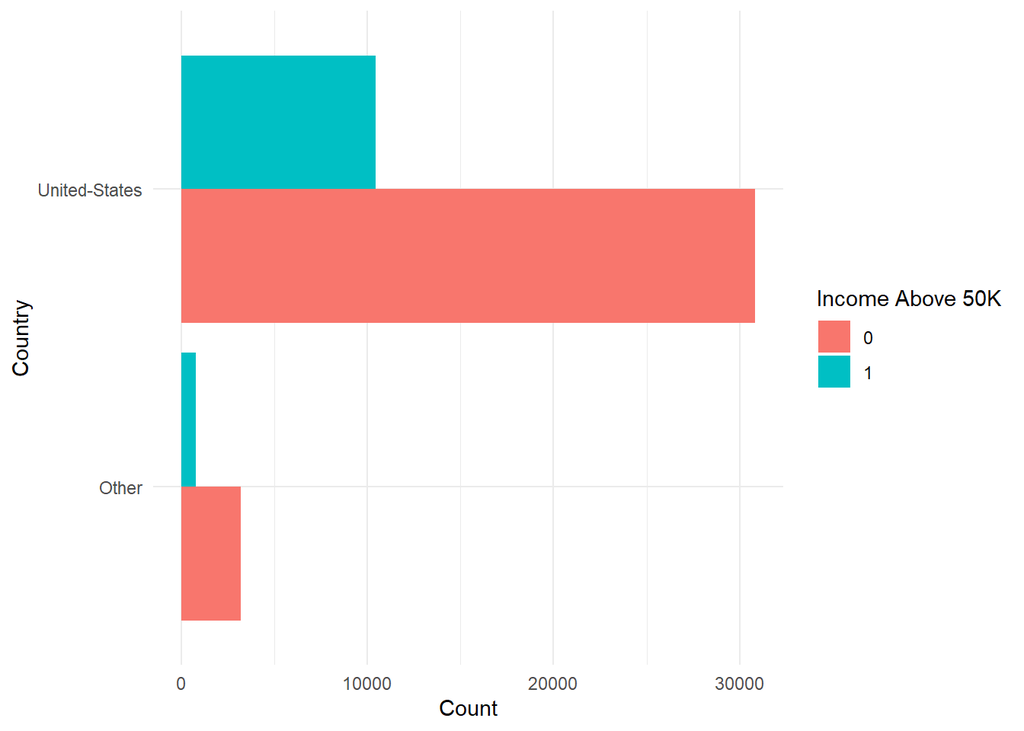

```r
# Replace all countries except the first one with 'Other'
countries <- unique(income2$`native-country`)
income2$`native-country` <- ifelse(income2$`native-country` %in% countries[-1], "Other", income2$`native-country`)

#Country vs Income
ggplot(income2, aes(y = `native-country`, fill = as.factor(income_above_50k))) +
  geom_bar(position = "dodge") +
  theme_minimal() +
  labs(y = "Country", x = "Count", fill = "Income Above 50K")
```

##Create dummy variables

```r
income2_dummies <- income2 %>%
  dummy_cols(select_columns = setdiff(names(income2), "income_above_50k"), remove_selected_columns = T)
```

##EDA pt2 (education smaller bins)

```r
income3 <- income2 %>%
  mutate(education = recode(education,
                            "School" = "Some_college_orless",
                            "Some-college" = "Some_college_orless",
                            "HS-grad" = "Some_college_orless",
                            "Assoc-voc" = "Some_college_orless",
                            "Assoc-acdm" = "Some_college_orless",
                            "Masters" = "Master_plus",
                            "Prof-school" = "Master_plus",
                            "Doctorate" = "Master_plus"
                            ))

education_counts <- income3 %>%
  count(education) %>%
  arrange(desc(n))

education_counts
```

| education | n |
| --- | --- |
| Some_college_orless | 33788 |
| Bachelors | 7570 |
| Master_plus | 3843 |

##Marital Status

```r
#unique names for marital status
unique(income3$`marital-status`)
```

```
## [1] "Never-married"         "Married-civ-spouse"    "Widowed"
## [4] "Separated"             "Divorced"              "Married-spouse-absent"
## [7] "Married-AF-spouse"
```

```r
#bin marital status
income3 <- income3 %>%
  mutate(`marital_status` = recode(`marital-status`,
                            "Never-married" = "never",
                            "Married-civ-spouse" = "married",
                            "Widowed" = "not_married",
                            "Separated" = "not_married",
                            "Divorced" = "not_married",
                            "Married-spouse-absent" = "married",
                            "Married-AF-spouse" = "married"
                            )) %>%
    select(-`marital-status`)
```

##Tuesday kappa.57 RF full dataset

```r
#
# income = read_csv("./openml_1590.csv", na=c("?")) %>%
#   drop_na() %>%
#   mutate(income_above_50k = class==">50K") %>%
#   select(-class) %>%
#   dummy_cols(remove_selected_columns = T)
#
# #income$income_above_50k <- as.factor(income$income_above_50k)
# income$income_above_50k <- factor(income$income_above_50k, levels = c(FALSE, TRUE), labels = c("Below_50K", "Above_50K"))
#
#
# #timer
# start_time <- Sys.time()
#
#
# # specify the model to be used (i.e. KNN, Naive Bayes, decision tree, random forest, bagged trees) and the tuning parameters used
# ctrl <- trainControl(method = "cv", number = 3, classProbs = TRUE, summaryFunction = twoClassSummary)
# set.seed(504)
#
# income_index <- createDataPartition(income$income_above_50k, p = 0.80, list = FALSE)
# train <- income[ income_index, ]
# test <- income[-income_index, ]
#
# #RF
# fit <- train(income_above_50k ~ .,
#              data = train,
#              method = "rf",
#              ntree = 20,
#              tuneLength = 3,
#              metric = "ROC",
#              trControl = ctrl)
#
# fit
#
# confusionMatrix(predict(fit, test),factor(test$income_above_50k))
#
#
# #end timer
# end_time <- Sys.time()
# time_taken <- end_time - start_time
# print(time_taken)
# print(as.numeric(time_taken, units = "mins"))
#
#
# # Naive Bayes
# fit_nb <- train(income_above_50k ~ .,
#                 data = train,
#                 method = "naive_bayes",
#                 metric = "ROC",
#                 trControl = ctrl)
#
# fit_nb
#
# confusionMatrix(predict(fit_nb, test), factor(test$income_above_50k))
#
# #error
# # KNN
# #fit_knn <- train(income_above_50k ~ .,
# #                 data = train,
# #                 method = "knn",
# #                 tuneLength = 10,
# #                 metric = "ROC",
# #                 trControl = ctrl)
#
# #fit_knn
#
# #confusionMatrix(predict(fit_knn, test), factor(test$income_above_50k))
#
# #error
# # K-Nearest Neighbors (KNN) with data normalization
# #fit_knn_normalized <- train(income_above_50k ~ .,
# #                            data = train,
# #                            method = "knn",
# #                            preProcess = "normalize", # Normalize the data
# #                            metric = "ROC",
# #                            trControl = ctrl)
#
# #fit_knn_normalized
#
# #confusionMatrix(predict(fit_knn_normalized, test), #factor(test$income_above_50k))
#
# #error
# #library(rpart)
# # Decision Tree (CART)
# #fit_cart <- train(income_above_50k ~ .,
# #                  data = train,
# #                  method = "rpart",
# #                  metric = "ROC",
# #                  trControl = ctrl)
#
# #fit_cart
#
# #confusionMatrix(predict(fit_cart, test), factor(test$income_above_50k))
#
#
# # SVM Support Vector Machine
# fit_svm <- train(income_above_50k ~ .,
#                  data = train,
#                  method = "svmRadial",
#                  tuneLength = 3,
#                  metric = "ROC",
#                  trControl = ctrl)
#
# fit_svm
#
# confusionMatrix(predict(fit_svm, test), factor(test$income_above_50k))
#
# # Logistic Regression Kappa .51
# fit_logreg <- train(income_above_50k ~ .,
#                     data = train,
#                     method = "glm",
#                     family = "binomial",
#                     metric = "ROC",
#                     trControl = ctrl)
#
# fit_logreg
#
# confusionMatrix(predict(fit_logreg, test), factor(test$income_above_50k))
#
# # Gradient Boosting Machine Kappa .51
# fit_gbm <- train(income_above_50k ~ .,
#                  data = train,
#                  method = "gbm",
#                  tuneLength = 3,
#                  metric = "ROC",
#                  trControl = ctrl)
#
# fit_gbm
#
# confusionMatrix(predict(fit_gbm, test), factor(test$income_above_50k))
#
# # XGBoost Kappa .53
# fit_xgb <- train(income_above_50k ~ .,
#                  data = train,
#                  method = "xgbTree",
#                  tuneLength = 3,
#                  metric = "ROC",
#                  trControl = ctrl)
#
# fit_xgb
#
# confusionMatrix(predict(fit_xgb, test), factor(test$income_above_50k))
#
```

##Multiple Accuracy measurements (Skip)

```r
# ctrl <- trainControl(method = "cv", number = 5, classProbs = TRUE, summaryFunction = defaultSummary)
#
# models <- list(
#   rf = train(income_above_50k ~ ., data = train, method = "rf", metric = "Accuracy", trControl = ctrl),
#   nb = train(income_above_50k ~ ., data = train, method = "nb", metric = "Accuracy", trControl = ctrl),
#   knn = train(income_above_50k ~ ., data = train, method = "knn", metric = "Accuracy", trControl = ctrl),
#   dt = train(income_above_50k ~ ., data = train, method = "rpart", metric = "Accuracy", trControl = ctrl)
# )
#
# results <- resamples(models)
# summary(results, metric = "Accuracy")
```

##Multiple Kappa (Skip)

```r
# ctrl <- trainControl(method = "cv", number = 5, classProbs = TRUE, summaryFunction = defaultSummary)
#
# models <- list(
#   rf = train(income_above_50k ~ ., data = train, method = "rf", metric = "Kappa", trControl = ctrl),
#   nb = train(income_above_50k ~ ., data = train, method = "nb", metric = "Kappa", trControl = ctrl),
#   knn = train(income_above_50k ~ ., data = train, method = "knn", metric = "Kappa", trControl = ctrl),
#   dt = train(income_above_50k ~ ., data = train, method = "rpart", metric = "Kappa", trControl = ctrl)
# )
#
# results <- resamples(models)
# summary(results, metric = "Kappa")
```

##Multiple AUC (Skip)

```r
# ctrl <- trainControl(method = "cv", number = 5, classProbs = TRUE, summaryFunction = twoClassSummary)
#
# # Train multiple models using different methods
# models <- list(
#   rf = train(income_above_50k ~ ., data = train, method = "rf", metric = "ROC", trControl = ctrl),
#   nb = train(income_above_50k ~ ., data = train, method = "nb", metric = "ROC", trControl = ctrl))#,
#   #knn = train(income_above_50k ~ ., data = train, method = "knn", metric = "ROC", trControl = ctrl),
#   #dt = train(income_above_50k ~ ., data = train, method = "rpart", metric = "ROC", trControl = ctrl)
# )
#
# # Evaluate the models using the chosen metrics
# results <- resamples(models)
#
# # Compare the models
# summary(results, metric = "ROC")
#
# #error
# prob <- predict(fit, newdata=test)
# pred <- ifelse(prob > 0.5, 1, 0)
# confusionMatrix(factor(pred),factor(test$income_above_50k))
# #error
# library(pROC)
# myRoc <- roc(test$income_above_50k, prob)
# plot(myRoc)
```

##Multiple F1 (Skip)

```r
#
# ctrl <- trainControl(method = "cv", number = 5, classProbs = TRUE, summaryFunction = prSummary)
#
# models <- list(
#   rf = train(income_above_50k ~ ., data = train, method = "rf", metric = "F1", trControl = ctrl),
#   nb = train(income_above_50k ~ ., data = train, method = "nb", metric = "F1", trControl = ctrl),
#   knn = train(income_above_50k ~ ., data = train, method = "knn", metric = "F1", trControl = ctrl),
#   dt = train(income_above_50k ~ ., data = train, method = "rpart", metric = "F1", trControl = ctrl)
# )
#
# results <- resamples(models)
# summary(results, metric = "F1")
```

##Tuesday pt2 EDA v1 variables kappa .41 RF

```r
#
# income = read_csv("./openml_1590.csv", na=c("?")) %>%
#   drop_na() %>%
#   mutate(income_above_50k = class==">50K") %>%
#   select(-class) #%>%
#   #dummy_cols(remove_selected_columns = T)
#
# #income$income_above_50k <- as.factor(income$income_above_50k)
# income$income_above_50k <- factor(income$income_above_50k, levels = c(FALSE, TRUE), labels = c("Below_50K", "Above_50K"))
#
# #New adds
#
# # Bin the 'age' column
# income <- income %>%
#   mutate(age_group = case_when(
#     age >= 0 & age <= 25 ~ "young",
#     age > 25 & age <= 65 ~ "prime",
#     age > 65 & age <= 100 ~ "retired"
#   )) %>%
#     select(-age)
#
# # Create 'Capital Diff' column and remove 'Capital Gain' and 'Capital Loss' columns
# income <- income %>%
#   mutate(capital_diff = `capital-gain` - `capital-loss`) %>%
#   select(-`capital-gain`, -`capital-loss`)
#
# # Bin the 'Capital Diff' column
# income <- income %>%
#   mutate(capital_diff = case_when(
#     capital_diff >= -5000 & capital_diff <= 5000 ~ "Minor",
#     capital_diff > 5000 & capital_diff <= 100000 ~ "Major"
#   ))
#
# #drop Columns
# income <- income %>% select(-fnlwgt)
#
# income <- income %>%
#   filter(workclass != "Without-pay")
#
# # Bin 'Hours per Week' column
# income <- income %>%
#   mutate(hours_per_week = case_when(
#     `hours-per-week` >= 0 & `hours-per-week` <= 32 ~ "part_time",
#     `hours-per-week` > 32 & `hours-per-week` <= 40 ~ "full_time",
#     `hours-per-week` > 40 & `hours-per-week` <= 100 ~ "overtime"
#   )) %>%
#     select(-`hours-per-week`)
#
# #Bin Education
# income <- income %>%
#   select(-`education-num`) %>%
#   mutate(education = recode(education,
#                             "11th" = "School",
#                             "9th" = "School",
#                             "7th-8th" = "School",
#                             "5th-6th" = "School",
#                             "10th" = "School",
#                             "1st-4th" = "School",
#                             "Preschool" = "School",
#                             "12th" = "School"
#                             ))
#
# #Race
# income <- income %>%
#   mutate(race = recode(race,
#                        "Black" = "Other",
#                        "Asian-Pac-Islander" = "Other",
#                        "Amer-Indian-Eskimo" = "Other",
#                        "Other" = "Other"
#                        ))
#
# # Replace all countries except the first one with 'Other'
# countries <- unique(income$`native-country`)
# income$`native-country` <- ifelse(income$`native-country` %in% countries[-1], "Other", income$`native-country`)
#
#
# #Create Dummy Variables
# income <- income %>%
#   dummy_cols(select_columns = setdiff(names(income), "income_above_50k"), remove_selected_columns = T)
#
# #income %>%
#   #dummy_cols(remove_selected_columns = T)
#
# #timer
# start_time <- Sys.time()
#
#
# # specify the model to be used (i.e. KNN, Naive Bayes, decision tree, random forest, bagged trees) and the tuning parameters used
# ctrl <- trainControl(method = "cv", number = 3, classProbs = TRUE, summaryFunction = twoClassSummary)
# set.seed(504)
#
# income_index <- createDataPartition(income$income_above_50k, p = 0.80, list = FALSE)
# train <- income[ income_index, ]
# test <- income[-income_index, ]
#
# # example spec for rf
# fit <- train(income_above_50k ~ .,
#              data = train,
#              method = "rf",
#              ntree = 20,
#              tuneLength = 3,
#              metric = "ROC",
#              trControl = ctrl)
#
# fit
#
# confusionMatrix(predict(fit, test),factor(test$income_above_50k))
#
#
# #end timer
# end_time <- Sys.time()
# time_taken <- end_time - start_time
# print(time_taken)
# print(as.numeric(time_taken, units = "mins"))
```

##Tuesday pt3 w/EDA pt2 variables RF Kappa .46

```r
#
# income = read_csv("./openml_1590.csv", na=c("?")) %>%
#   drop_na() %>%
#   mutate(income_above_50k = class==">50K") %>%
#   select(-class) #%>%
#   #dummy_cols(remove_selected_columns = T)
#
# #income$income_above_50k <- as.factor(income$income_above_50k)
# income$income_above_50k <- factor(income$income_above_50k, levels = c(FALSE, TRUE), labels = c("Below_50K", "Above_50K"))
#
# #New adds
#
# # Bin the 'age' column
# income <- income %>%
#   mutate(age_group = case_when(
#     age >= 0 & age <= 25 ~ "young",
#     age > 25 & age <= 65 ~ "prime",
#     age > 65 & age <= 100 ~ "retired"
#   )) %>%
#     select(-age)
#
# # Create 'Capital Diff' column and remove 'Capital Gain' and 'Capital Loss' columns
# income <- income %>%
#   mutate(capital_diff = `capital-gain` - `capital-loss`) %>%
#   select(-`capital-gain`, -`capital-loss`)
#
# # Bin the 'Capital Diff' column
# income <- income %>%
#   mutate(capital_diff = case_when(
#     capital_diff >= -5000 & capital_diff <= 5000 ~ "Minor",
#     capital_diff > 5000 & capital_diff <= 100000 ~ "Major"
#   ))
#
# #drop Columns
# income <- income %>% select(-fnlwgt)
#
# income <- income %>%
#   filter(workclass != "Without-pay")
#
# # Bin 'Hours per Week' column
# income <- income %>%
#   mutate(hours_per_week = case_when(
#     `hours-per-week` >= 0 & `hours-per-week` <= 32 ~ "part_time",
#     `hours-per-week` > 32 & `hours-per-week` <= 40 ~ "full_time",
#     `hours-per-week` > 40 & `hours-per-week` <= 100 ~ "overtime"
#   )) %>%
#     select(-`hours-per-week`)
#
# #Bin Education
# income <- income %>%
#   select(-`education-num`) %>%
#   mutate(education = recode(education,
#                             "11th" = "School",
#                             "9th" = "School",
#                             "7th-8th" = "School",
#                             "5th-6th" = "School",
#                             "10th" = "School",
#                             "1st-4th" = "School",
#                             "Preschool" = "School",
#                             "12th" = "School"
#                             ))
#
# #Race
# income <- income %>%
#   mutate(race = recode(race,
#                        "Black" = "Other",
#                        "Asian-Pac-Islander" = "Other",
#                        "Amer-Indian-Eskimo" = "Other",
#                        "Other" = "Other"
#                        ))
#
# # Replace all countries except the first one with 'Other'
# countries <- unique(income$`native-country`)
# income$`native-country` <- ifelse(income$`native-country` %in% countries[-1], "Other", income$`native-country`)
#
#
# #Education further binned
# income <- income %>%
#   mutate(education = recode(education,
#                             "School" = "Some_college_orless",
#                             "Some-college" = "Some_college_orless",
#                             "HS-grad" = "Some_college_orless",
#                             "Assoc-voc" = "Some_college_orless",
#                             "Assoc-acdm" = "Some_college_orless",
#                             "Masters" = "Master_plus",
#                             "Prof-school" = "Master_plus",
#                             "Doctorate" = "Master_plus"
#                             ))
#
# #occupation further binned
# income <- income %>%
#   mutate(occupation = recode(occupation,
#                             "Exec-managerial" = "high_tier",
#                             "Prof-specialty" = "high_tier",
#                             "Sales" = "mid_tier",
#                             "Craft-repair" = "mid_tier",
#                             "Adm-clerical" = "mid_tier",
#                             "Transport-moving" = "low_tier",
#                             "Tech-support" = "low_tier",
#                             "Machine-op-inspct" = "low_tier",
#                             "Protective-serv" = "low_tier",
#                             "Other-service" = "low_tier",
#                             "Farming-fishing" = "low_tier",
#                             "Handlers-cleaners" = "low_tier",
#                             "Armed-Forces" = "low_tier",
#                             "Priv-house-serv" = "low_tier"
#                             ))
#
# #further binned marital status
# income <- income %>%
#   mutate(`marital_status` = recode(`marital-status`,
#                             "Never-married" = "never",
#                             "Married-civ-spouse" = "married",
#                             "Widowed" = "not_married",
#                             "Separated" = "not_married",
#                             "Divorced" = "not_married",
#                             "Married-spouse-absent" = "married",
#                             "Married-AF-spouse" = "married"
#                             )) %>%
#     select(-`marital-status`)
#
#
#
#
# #Create Dummy Variables
# income <- income %>%
#   dummy_cols(select_columns = setdiff(names(income), "income_above_50k"), remove_selected_columns = T)
#
# #income %>%
#   #dummy_cols(remove_selected_columns = T)
#
# #timer
# start_time <- Sys.time()
#
#
# # specify the model to be used (i.e. KNN, Naive Bayes, decision tree, random forest, bagged trees) and the tuning parameters used
# ctrl <- trainControl(method = "cv", number = 3, classProbs = TRUE, summaryFunction = twoClassSummary)
# set.seed(504)
#
# income_index <- createDataPartition(income$income_above_50k, p = 0.80, list = FALSE)
# train <- income[ income_index, ]
# test <- income[-income_index, ]
#
# # example spec for rf
# fit <- train(income_above_50k ~ .,
#              data = train,
#              method = "rf",
#              ntree = 20,
#              tuneLength = 3,
#              metric = "ROC",
#              trControl = ctrl)
#
# fit
#
# confusionMatrix(predict(fit, test),factor(test$income_above_50k))
#
#
# #end timer
# end_time <- Sys.time()
# time_taken <- end_time - start_time
# print(time_taken)
# print(as.numeric(time_taken, units = "mins"))
```